# In-term III, M362M Spring 2024

*Instructions*:

- Problem 1 is computational, but you are not allowed to use simulations/Monte Carlo. Submit its solution in pdf (knitted from Rmd) just like you would submit your HW. Make sure to **submit the Rmd file you used to knit the pdf**. Submitting only the pdf file will result in a 50% penalty.
- Problems 2 is “theoretical” - its solution can be submitted as a pdf scan of hand-written pages (or knitted Rmds if you know LaTeX). You are allowed to use R to manipulate matrices and solve linear systems, but everything is doable by hand.
- If you have any questions, please post them on Ed Discussion.

## Problem 1.

*The bold play* is a version of *Gambler’s ruin* where a gambler starts with the “wealth” $x \in \{1,2,\dots, a-1\}$ and tries to make $a$ before going bankrupt (hitting $0$). Unlike in the classical Gambler’s ruin - which we call *the timid play* here, the player does not bet $1$ each time. She plays “boldly” and bets the maximum possible amount that makes sense. More precisely, if her current wealth is $x$, she bets either $x$ or $a-x$, whichever is smaller. Assume that each game is a coin toss with probability $p\in (0,1)$ of getting *heads*. If that happens, the gambler’s wealth increases by the amount she bet. If the coin shows *tails* she loses the bet, and her wealth decreases by the same amount. As in the timid Gambler’s ruin, the gambler stops when either $0$ or $a$ is reached (and we assume that her wealth remains at that level forever).

1. Write an R function which takes arguments $a\geq 3$ and $p \in (0,1)$ and outputs the transition matrix of the Markov chain that models the bold play. Show its output for $a=5$ and $p=0.6$.
2. Write an R function which takes arguments $a\geq 3$ and $p\in (0,1)$ and outputs the (vector of) *ruin probabilities* (i.e., probabilities that the gambler using the bold-play strategy will go bankrupt before her wealth reaches $\$a$) for each initial wealth $x = 0,1,\dots, a-1, a$. Show its output for $a=5$ and $p=0.6$.
3. For $a=1000$ and each $p$ in $\{ 0.1, 0.3, 0.4, 0.5, 0.6, 0.7, 0.9\}$ plot a graph which contains two curves: one with ruin probabilities for the bold play as a function of the initial wealth you just computed in b., and a similar one for the timid strategy with the same $a$ and $p$. Use two different colors. Which strategy is better?

## Solution

1. Let us first display the transition graph of the chain for $a=5$ (green edges have probability $p$ and orange $1-p$):

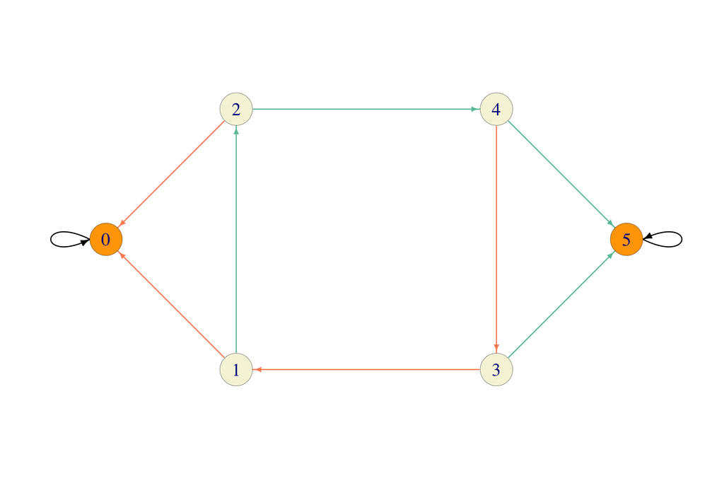

   In order to build the transition matrix, we start with a zero matrix and fill in the non-zero values in a for loop:

   ```r
   bold_play_transition_matrix <- function(a, p) {
           P = matrix(0, ncol = a + 1, nrow = a + 1)
           P[1, 1] = 1
           P[a + 1, a + 1] = 1
           for (x in 1:(a - 1)) {
                   l = min(x, a - x)
                   P[x + 1, x + l + 1] = p
                   P[x + 1, x - l + 1] = 1 - p
           }
           return(P)
   }

   (bold_play_transition_matrix(5,0.6))
   ```

   ```
   ##      [,1] [,2] [,3] [,4] [,5] [,6]
   ## [1,]  1.0  0.0  0.0  0.0  0.0  0.0
   ## [2,]  0.4  0.0  0.6  0.0  0.0  0.0
   ## [3,]  0.4  0.0  0.0  0.0  0.6  0.0
   ## [4,]  0.0  0.4  0.0  0.0  0.0  0.6
   ## [5,]  0.0  0.0  0.0  0.4  0.0  0.6
   ## [6,]  0.0  0.0  0.0  0.0  0.0  1.0
   ```

2. We need to perform the absorption-and-reward computation here. The transition matrix has already been built in part a. The only recurrent states are $0$ and $a$ (corresponding to rows/columns $1$ and $a+1$), so the function that computes the probability of going bankrupt, as a function of $a$ and $p$, looks like this:

   ```r
   ruin_probability_bold <- function(a,p) {
    P = bold_play_transition_matrix(a,p)
    Q = P[ 2:a , 2:a ]
    R = P[ 2:a , c(1,a+1) ]
    return(c(1,solve(diag(a-1)-Q, R)[,1],0))
   }

   (ruin_probability_bold(5,0.6))
   ```

   ```
   ## [1] 1.0000000 0.6791171 0.4651952 0.2716469 0.1086587 0.0000000
   ```

3. We borrow (and minimally adjust) the function `ruin_probability` from the problem about Gambler’s ruin above:

   ```r
   ruin_probability_timid= function(a, p) {
           P = matrix(0, ncol = a + 1, nrow = a + 1)
           P[1, 1] = 1
           P[a + 1, a + 1] = 1
           for (i in 2:a) {
                   P[i, i - 1] = 1 - p
                   P[i, i + 1] = p
           }

           Q = P[2:a, 2:a]
           R = P[2:a, c(1, a + 1)]
           c(1, solve(diag(a - 1) - Q, R)[, 1], 0)
   }
   ```

   Then we write a function which will draw the two curves on top of each other, and call it for each value of $p$:

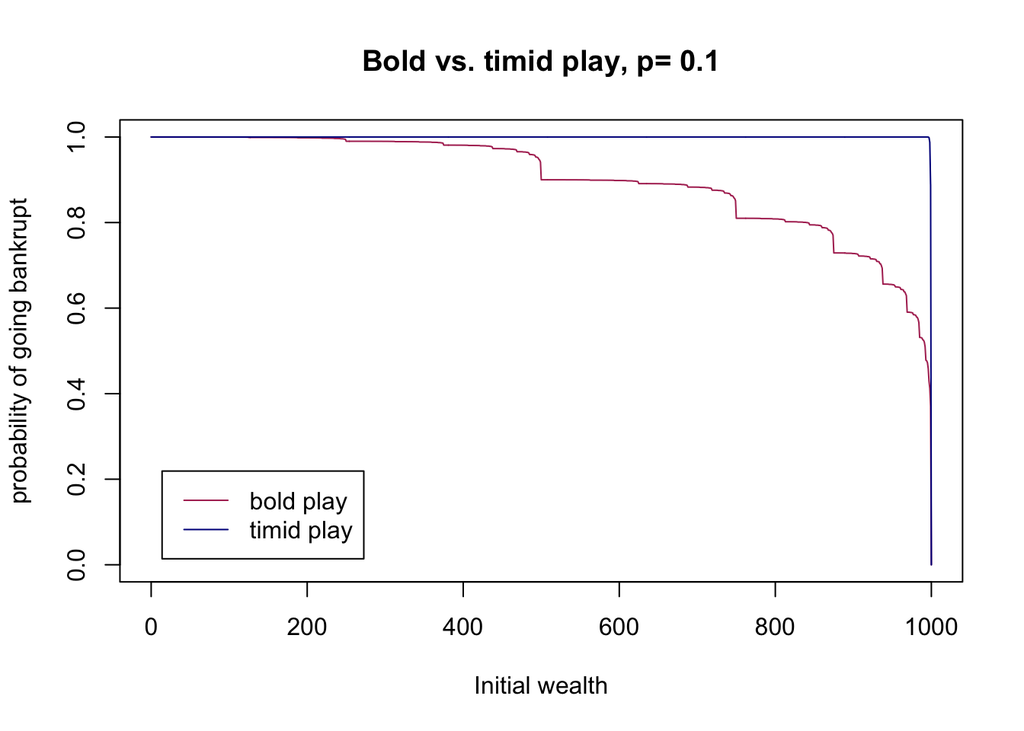

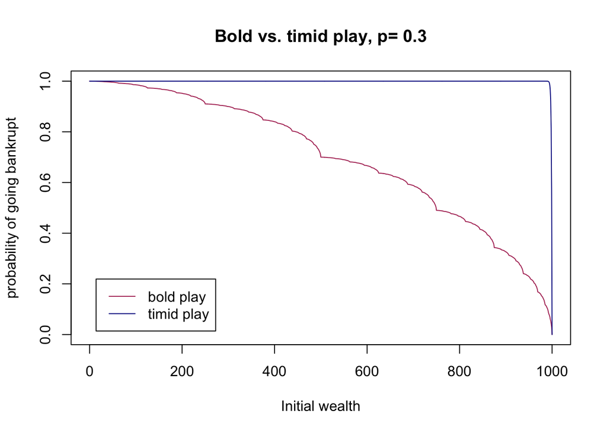

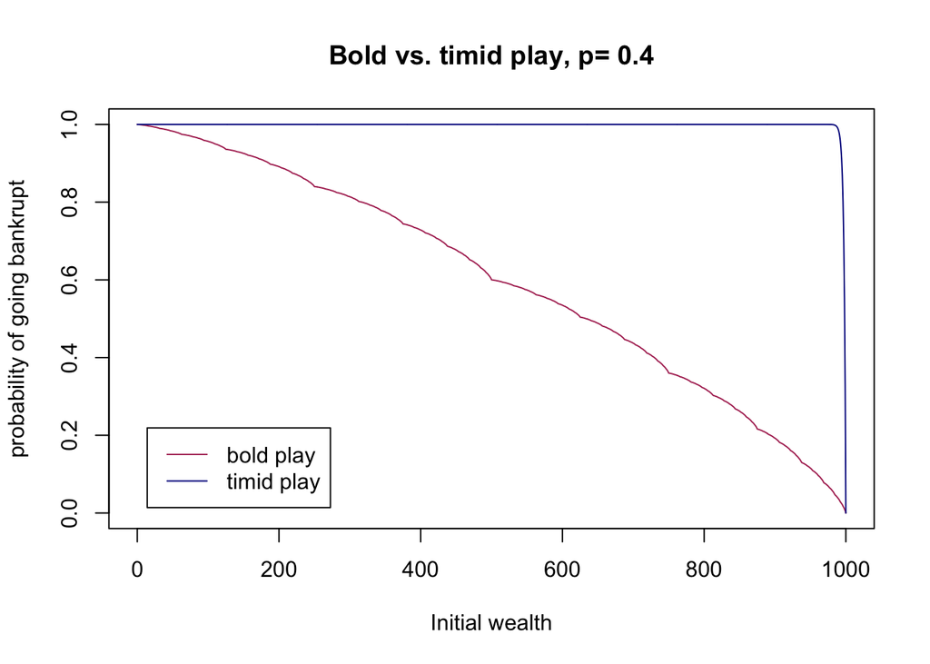

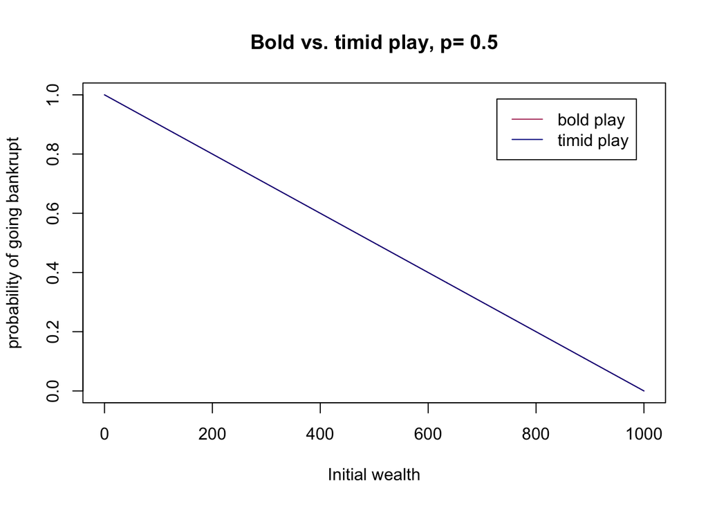

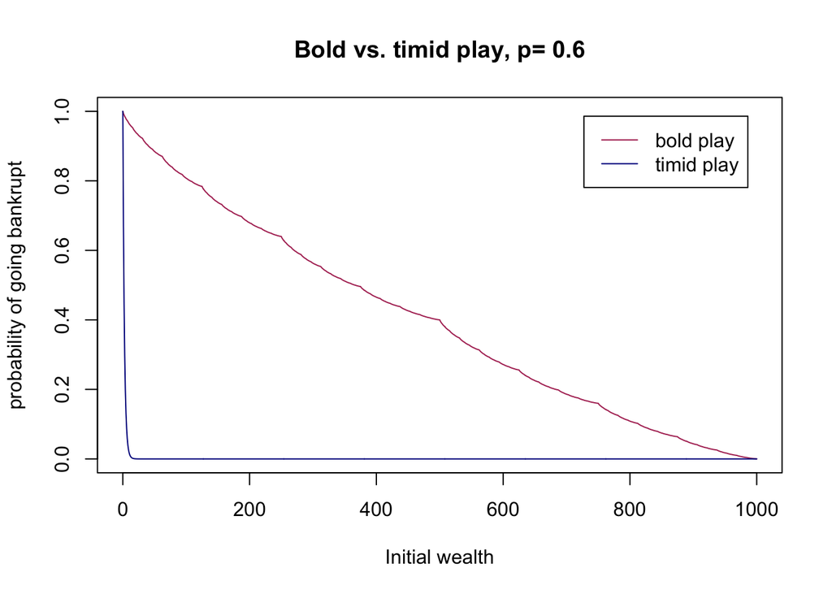

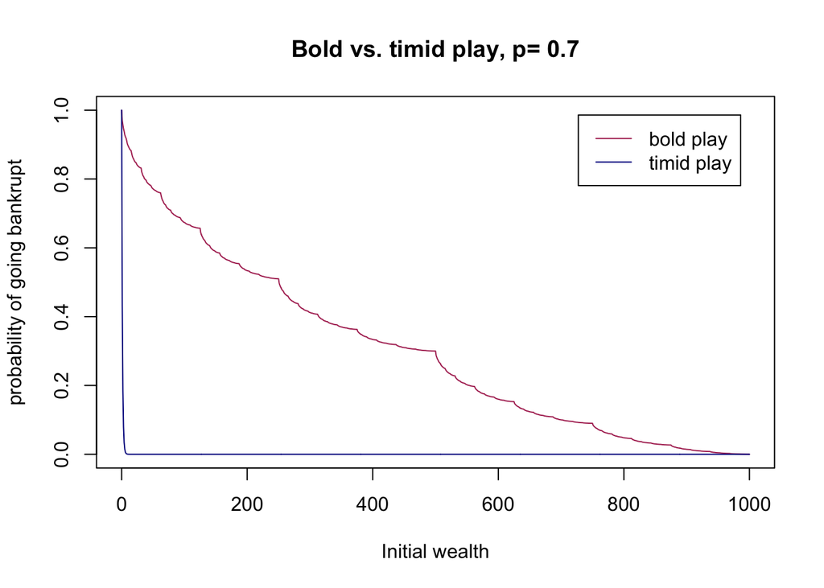

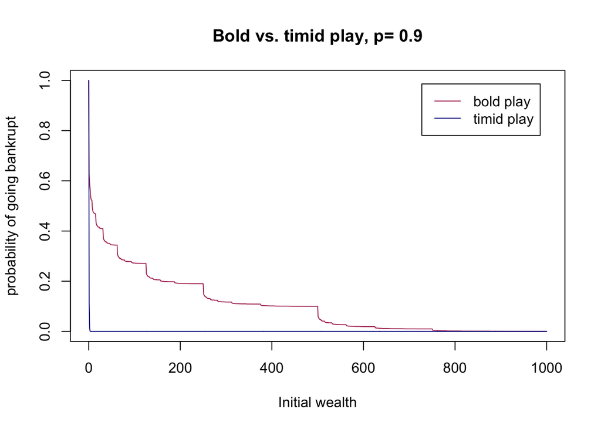

   ```r
   plot_two_strategies = function(a,p){
           plot(
                   0:a , ruin_probability_bold(a,p),
                   main = paste("Bold vs. timid play, p=",p),
                   ylab = paste("probability of going bankrupt"),
                   xlab = "Initial wealth",
                   type = "l", col = "maroon",
                   ylim = c(0, 1), lwd = 1 )

           points( 0:a , ruin_probability_timid(a,p),
                  type = "l", col = "darkblue", lwd = 1 )

           # tweaking the placement of the legend box (not important)
           legend_position = "topright"
           if (p<0.5) legend_position = "bottomleft"

           legend( legend_position, inset = 0.05,
                   legend = c("bold play", "timid play"),
                   col = c("maroon", "darkblue"), lty = 1, lwd = 1 )
   }

   for (p in c(0.1, 0.3, 0.40, 0.5, 0.6, 0.7, 0.9)) {
           plot_two_strategies(1000, p)
   }
   ```

## Problem 2.

An Instagram influencer and die-hard foodie Ravi travels for work between Austin and Los Angeles. After he spends a week in Austin, he spends another week there with probability $1/3$ or goes to Los Angeles with probability $2/3$. After a week in Los Angeles, he always spends the next week in Austin.

His friend, Delphine, a tech enterpreneur and a passionate restaurant-goer herself, keeps a similar schedule. She also moves between Austin and Los Angeles, but, being a free spirit (and also a bit detached from reality), she makes her decisions by tossing a coin. No matter where she is, Austin or Los Angeles, she stays there with probability $1/2$ for another week, or switches cities with probability $1/2$, as well. Moreover, the coin she uses is just a coin - it is not magically influenced by Ravi’s current position in any way. Similarly, Ravi’s decision whether to stay or not has nothing to do with Delphine’s coin, or the city she is in.

Each time Ravi and Delphine find themselves in the same city, they go out on Friday night to try a new restaurant. If they happen to be in Austin, they pay $\$100$ for the experience. Los Angeles is more expensive, and the typical dinner costs $\$200$.

1. Ravi and Delphine are in Los Angeles this week. How many weeks will pass (on average) before they are both in Los Angeles again?
2. How many Austin dinners do they have, on average, between two Los Angeles dinners?
3. What is the long-run average amount of money they spend on restaurants each week?

## Solution

We model the positions of Ravi and Delphine by a Markov chain with $4$ states AA, AL, LA and LL (with the two letters denoting the cities they happen do find themselves in a given week). Ravi’s and Delphine’s positions, considered separately, are also Markov Chains, with the state space $\{A,L\}$ and the transition matrices
$$P^{R} = \begin{bmatrix} 1/3 & 2/3 \\ 1 &
0\end{bmatrix} \text{ and }P^{D} = \begin{bmatrix} 1/2 & 1/2 \\ 1/2
&
1/2\end{bmatrix}.$$
Since Ravi’s and Delphine’s transitions are independent, the transition probabilities of the “joint” chain on $S = \{\text{AA, AL, LA, LL}\}$ are simply products of the transition probability of the two individual chains. For example $P_{AA, AL} = P^{\text{Ravi}}_{A, A}\times P^{\text{Delphine}}_{A,L} = 1/3 \times 1/2 = 1/6$. Therefore, the full transition matrix for the “joint” chain is given by
$$P = \begin{bmatrix}
1/6 & 1/6 & 1/3 & 1/3 \\
1/6 & 1/6 & 1/3 & 1/3 \\
1/2 & 1/2 & 0 & 0 \\
1/2 & 1/2 & 0 & 0
\end{bmatrix}$$
with the states in the following order AA, AL, LA and LL. All the questions above use the stationary probability of this chain, so we compute it first. The system of equations for $\pi = (\pi_{AA}, \pi_{AL}, \pi_{LA}, \pi_{LL})$ is
$$\begin{aligned}
\pi_{AA} &= 1/6 \pi_{AA} + 1/6 \pi_{AL} + 1/2 \pi_{LA} + 1/2
\pi_{LL} \\
\pi_{AL} &= 1/6 \pi_{AA} + 1/6 \pi_{AL} + 1/2 \pi_{LA} + 1/2
\pi_{LL} \\
\pi_{LA} &= 1/3 \pi_{AA} + 1/3 \pi_{AL}\\
\pi_{LL} &= 1/3 \pi_{AA} + 1/3 \pi_{AL}\\
\text{ as well as} \\
1 = & \pi_{AA}+\pi_{AL} + \pi_{LA} +
\pi_{LL}.\end{aligned}$$
The first two equations immediately imply that $\pi_{AA} = \pi_{AL}$, and the second two that $\pi_{LA} = \pi_{LL}$. Moreover, by the third equation, we have $\pi_{LA} = 2/3 \pi_{AA}$; similarly, $\pi_{LL} = 2/3 \pi_{AL} = 2/3 \pi_{AA}$. We plug all of that into the last equation to get
$$1 = \pi_{AA} + \pi_{AA} + 2/3 \pi_{AA} + 2/3
\pi_{AA},$$
which gives $\pi_{AA} = 3/10$, and, then, $\pi_{AL} = 3/10$, $\pi_{LA} = 1/5$ and $\pi_{LL} = 1/5$.

1. By Kac’s theorem, the mean return time to LL is $1/\pi_{LL} = 5$ weeks.
2. Also by Kac’s theorem, the average number of visits to AA between two visits to LL is $\pi_{AA}/\pi_{LL} = 1.5$
3. By the ergodic theorem, the long-run amount of money spent each week is $\pi_{AA} \times \$100 + \pi_{LL}\times \$200 = \$ 70$.